# Practical 2 - Question 10

Cas Blaauw, Dominic Comerford and Netanja Harlianto

12/05/2020

## Setup

```r
library(tidyverse)
library(gganimate)
library(gifski)
```

## Importing and exploring the data

```r
head(txhousing)
```

```
## # A tibble: 6 x 9
##   city     year month sales   volume median listings inventory  date
##   <chr>   <int> <int> <dbl>    <dbl>  <dbl>    <dbl>     <dbl> <dbl>
## 1 Abilene  2000     1    72  5380000  71400      701       6.3 2000
## 2 Abilene  2000     2    98  6505000  58700      746       6.6 2000.
## 3 Abilene  2000     3   130  9285000  58100      784       6.8 2000.
## 4 Abilene  2000     4    98  9730000  68600      785       6.9 2000.
## 5 Abilene  2000     5   141 10590000  67300      794       6.8 2000.
## 6 Abilene  2000     6   156 13910000  66900      780       6.6 2000.
```

```r
txhousing %>%
  group_by(city) %>%
  summarise(sum = sum(listings, na.rm = T)) %>%
  arrange(desc(sum))
```

```
## # A tibble: 46 x 2
##    city                  sum
##    <chr>               <dbl>
##  1 Houston           5491834
##  2 Dallas            4052774
##  3 San Antonio       1768445
##  4 Austin            1626229
##  5 Collin County      881379
##  6 Fort Worth         751320
##  7 Fort Bend          651650
##  8 Montgomery County  610515
##  9 NE Tarrant County  560029
## 10 Bay Area           557853
## # ... with 36 more rows
```

# Gathering the biggest cities

```r
txcities <- txhousing %>% #Gather the 8 biggest real estate markets
  group_by(city) %>%
  summarise(sum = sum(listings, na.rm = T)) %>%
  arrange(desc(sum)) %>%
  pull(city) %>%
  .[1:8]
```

## Making the plot

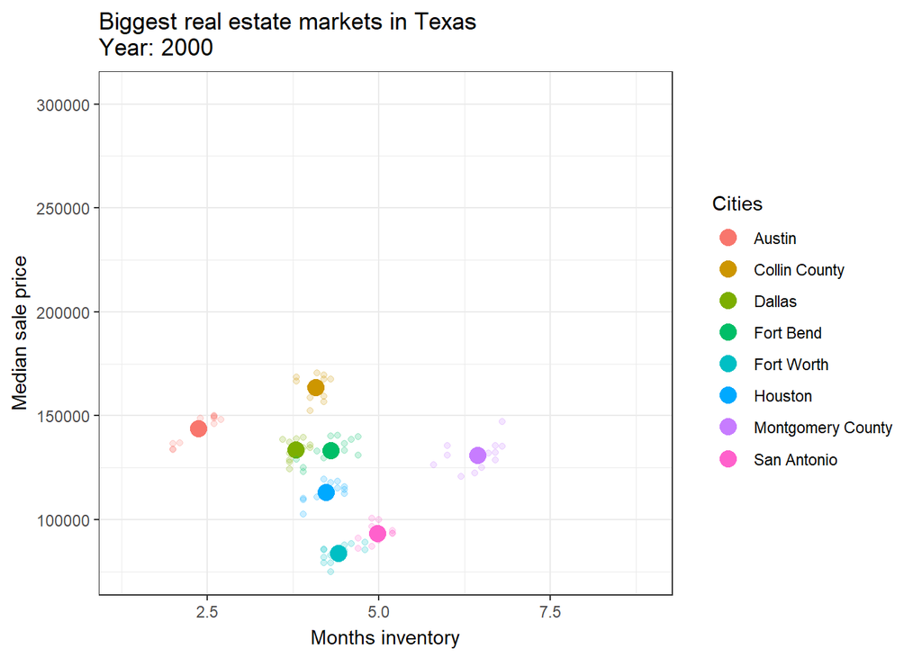

```r
txtop <-
  txhousing %>%
  filter(city %in% txcities) %>%
  group_by(city, year)

txsummary <-
  txtop %>%
  summarise(meaninv = mean(inventory, na.rm = T),
            meanmed = mean(median, na.rm = T),
            sumlist = sum(listings, na.rm = T)/1000)
txplot <-
  ggplot() +
  geom_point(data = txsummary,
             aes(meaninv, meanmed, col=city), size = 4) +
  transition_time(year) +
  labs(title = "Biggest real estate markets in Texas \n Year: {frame_time}") +
  xlab('Months inventory') +
  ylab('Median sale price') +
  theme_bw() +
  labs(col = "Cities")

txplot + geom_point(data = txtop, aes(inventory, median, col=city), alpha = 0.2)
```

Our plot displays the Median Sale Price of houses (Y-axis) in the 8 biggest Texan cities (selected on total listings) against the expected duration in months it would take to sell all listed houses per year (2000-2015). There are some clear patterns that distinguish the cities from one another. First of all, the median selling price of houses in Collin County, Austin and Ford Bend are apparently higher than in other areas, as well as that this median is evidently lowest in Fort Worth. San Antonio starts off with a low median selling price, but here the median selling prices increases fast around the year 2005. Secondly, it seems as though the impact of the economic crisis (2008) did not so much affect median selling prices, but rather the expected duration to sell and that in the years after the crisis the median selling prices in all areas rapidly grew, as well as that expected duration of selling decreased.